# ncov-recombinant v0.6.1 - v0.7.0

Test Summary Package

*This report was automatically generated on February 22, 2023.*

## Authors

**Katherine Eaton** | National Microbiology Laboratory, PHAC | katherine.eaton@phac-aspc.gc.ca

## 1. Summary

The `ncov-recombinant` update from `v0.6.1` to `v0.7.0` has 3 major changes.

The first change is a `nextclade` dataset upgrade from `2022-10-27` to `2023-02-01` which adds nomenclature for newly designated recombinants XBH to XBP.

The second change is detection of recursive recombinants, XBL and XBN which arose from two separate recombination events between BA.2.75* and XBB*. Currently, recursive recombination is only set to be detected between XBB and VOC circulating in late 2022 and early 2023.

The third major change is that all documentation has been migrated to [Read The Docs](https://ncov-recombinant.readthedocs.io/en/latest/). This includes a detailed [Developer’s Guide](https://ncov-recombinant.readthedocs.io/en/latest/developers_guide.html) for those looking to contribute to the project.

Between `v0.6.1` and `v0.7.0`, **15.2%** of sequences in the `controls-gisaid` dataset had different detection results. **5.1%** of sequences were newly classified (NA → X*) and represent lineages not present in the `v0.6.1` model. **6.6%** of sequences had *lineage* assignment changes and **3.5%** of sequences had *sublineage* assignment changes as a result of the `Nextclade` dataset upgrade. **0%** of positive controls were dropped (X* → NA), indicating no observed loss in sensitivity.

`ncov-recombinant` `v0.7.0` is a recommended upgrade for recombinant surveillance to accurately classify the latest recombinant lineages (up to XBP) and to detect recursive recombination (ex. XBL is a recombinant of XBB).

For a comprehensive summary of the methodological changes, please see the [release notes for v0.7.0](https://github.com/ktmeaton/ncov-recombinant/releases/tag/v0.7.0)

## 2. Purpose

Verify that the update of ncov-recombinant pipeline from version `0.6.1` to`0.7.0`:

1. Maintains specificity for recombinants trained in previous versions.
2. Increases sensitivity for newly designated recombinant sublineages.

## 3. Datasets

### Controls

This dataset includes SARS-CoV-2 genomes from GISAID that reflect the known diversity of recombinant sequences to date. These include `572` positive controls (recombinants), representing lineages XA - XBP and `186` negative controls (non-recombinants) selected from the [Nextstrain Reference Phylogeny](https://nextstrain.org/ncov/gisaid/reference).

In total, `758` control sequences were used as input and a [strain list is available here](https://raw.githubusercontent.com/ktmeaton/ncov-recombinant/v0.7.0/data/controls-gisaid/strains.txt).

### Canada VirusSeq

This dataset includes publicly available SARS-CoV-2 genomes from the [Canadian VirusSeq Data Portal](https://virusseq-dataportal.ca/). Sequences were downloaded on 2023-01-23 and include 441,234 genomes in total.

## 4. Procedure

The snakemake pipelines for `v0.6.1` and `v0.7.0` were run independently on the `controls-gisaid` and `virusseq` datasets. Please see the Procedure section of the Supplementary for detailed command-line instructions.

## 5. Results

### Controls GISAID

- **84.8%** (485/572) of lineage assignments were unchanged (Figure 1).
- **5.1%** (29/572) of sequences were newly classified as recombinants.
- **6.6%** (38/572) of sequences changed *lineage* assignments.
- **3.5%** (20/572) of sequences changed *sublineage* assignments (ex. `XBB.1` → `XBB.1.5`).
- **0.0%** (0/572) of sequences were dropped as positives (`NA`).

> **Note**: Lineage assignments in `v0.7.0` are identical to those in pango-designation and are the expected values.

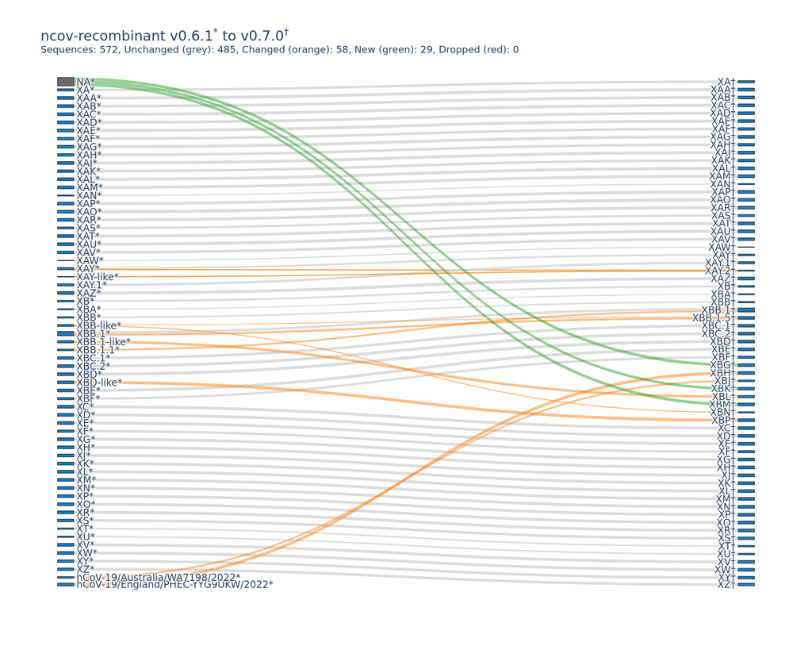

Figure 1: Comparison of lineage assignments in the `controls-gisaid` dataset between `v0.6.1` and `v0.7.0`.

### Canada VirusSeq

- **66.3%** (862/1300) of lineage assignments were unchanged (Figure 2).
- **7.8%** (101/1300) of sequences were newly classified as recombinants.
- **1.5%** (20/1300) of sequences changed *lineage* assignments.
- **21.9%** (285/1300) of sequences changed *sublineage* assignments (ex. `XBB.1` → `XBB.1.5`).
- **2.5%** (32/1300) of sequences were dropped as positives (`NA`).

> **Note**: Lineage assignments in `v0.7.0` are identical to those in pango-designation and are the expected values.

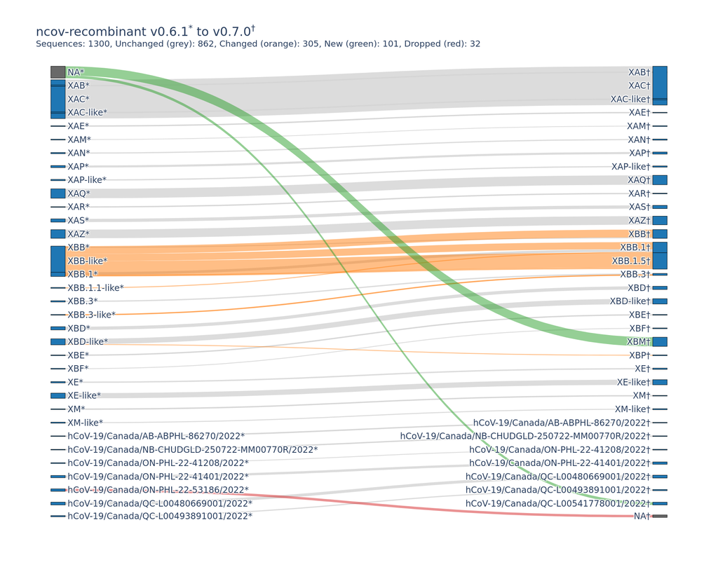

### Changes

#### New Detections

**New detections** (`NA` → `X*`) result from the following changes in `v0.7.0`:

1. Nextclade dataset upgrades to include newly designated lineages: XBG, XBK, XBM.

   | Lineage (`v0.7.0`) | Lineage (`v0.6.0`) | Parents |
   | --- | --- | --- |
   | XBG | NA | BA.2.76*, BA.5.2* |
   | XBK | NA | BA.5.2*, CJ.1* |
   | XBM | NA | BA.2.76*, BF.3* |

#### Lineage Changes

**Lineage changes** result from the following updates in `v0.7.0`:

1. Nextclade dataset upgrades to include newly designated lineages: XBH, XBJ, XBL, XBN, XBP.

   | Lineage (`v0.7.0`) | Lineage (`v0.6.0`) | Parents |
   | --- | --- | --- |
   | XBH | BY.1 | BA.2.3*, BA.2.75* |
   | XBJ | BA.2.3.20 | BA.2.3*, BA.5.2* |
   | XBL | XBB.1-like | BA.2.75*, XBB* |
   | XBN | XBB-like | BA.2.75*, XBB* |
   | XBP | XBD-like | BA.2.75*,* BA.5* |

**Sublineage changes** result from the following updates in `v0.7.0`:

1. Nextclade dataset upgrades to include new sublineages for: XAY and XBB.

   | Lineage (`v0.7.0`) | Lineage (`v0.6.0`) | Parents |
   | --- | --- | --- |
   | XAY.2 | XAY, XAY-like | BA.2*, Delta (21J) |
   | XBB.1 | XBB.1.1 | BA.2.10*, BA.2.75* |
   | XBB.1.5 | XBB.1, XBB-like | BA.2.10*, BA.2.75* |

#### Dropped Positives

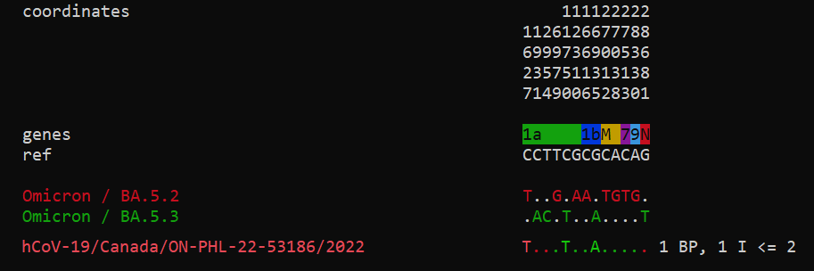

## Acknowledgements

The results here are in whole, or in part based upon data hosted at the Canadian VirusSeq Data Portal: https://virusseq-dataportal.ca/. We wish to acknowledge the Canadian Public Health Laboratory Network (CPHLN), Genome Canada and the CanCOGeN VirusSeq Consortium for their contribution to the Portal.

## Supplementary

### Procedure

#### Download Data

1. Download the GISAID sequences and metadata in the [strains list](https://raw.githubusercontent.com/ktmeaton/ncov-recombinant/v0.6.0/data/controls-gisaid/strains.txt) from [GISAID](https://gisaid.org/) to `data/controls-gisaid/`.
2. Download the VirusSeq sequences and metadata.

   ```bash
   wget -O virusseq.tar.gz https://singularity.virusseq-dataportal.ca/download/archive/2d9ace2c-0808-475f-bc93-6ad5808581a4
   tar -xvf virusseq.tar.gz

   mkdir data/virusseq

   # Prep metadata
   csvtk cut -t -f "fasta header name,sample collection date,geo_loc_name (country),geo_loc_name (state/province/territory)" *files-archive*.tsv \
       | csvtk rename -t -f "fasta header name" -n "strain" \
       | csvtk rename -t -f "sample collection date" -n "date" \
       | csvtk rename -t -f "geo_loc_name (country)" -n "country" \
       | csvtk rename -t -f "geo_loc_name (state/province/territory)" -n "division" \
       > data/virusseq/metadata.tsv

   # Prep sequences
   mv *files-archive*.fasta data/virusseq/sequences.fasta

   # Cleanup
   rm *files-archive*.tsv
   rm virusseq.tar.gz
   ```

#### Version 0.7.0 | 3f3d4438

3f3d4438c5af7584f760855edd620ef162fb1b1e

1. Download the pipeline.

   ```bash
   git clone https://github.com/ktmeaton/ncov-recombinant.git 0.7.0
   cd 0.7.0
   git checkout v0.7.0
   ```

2. Create a version-controlled conda environment.

   ```bash
   # Local
   mamba env create -f workflow/envs/environment.yaml -n ncov-recombinant-0.7.0

   # HPC
   sbatch -J conda-ncov-recombinant-0.7.0 --wrap="mamba env create -f workflow/envs/environment.yaml -n ncov-recombinant-0.7.0"
   ```

3. Symlink the `controls-gisaid` data.

   ```bash
   ln -s ../../../data/controls-gisaid/metadata.tsv data/controls-gisaid/metadata.tsv
   ln -s ../../../data/controls-gisaid/sequences.fasta data/controls-gisaid/sequences.fasta
   ```

4. Symlink the `virusseq` data.

   ```bash
   ln -s ../../data/virusseq data/virusseq
   ```

5. Run the pipeline for `controls-gisaid`.

   ```bash
   # Local
   conda activate ncov-recombinant-0.7.0
   snakemake --profile profiles/controls-gisaid

   # HPC
   scripts/slurm.sh --profile profiles/controls-gisaid-hpc --conda-env ncov-recombinant-0.7.0
   ```

6. Run the pipeline for `virusseq` (must be done as HPC).

   ```bash
   scripts/slurm.sh --profile profiles/virusseq-hpc --conda-env ncov-recombinant-0.7.0
   ```

   - Note: The pipeline will likely fail to run *_historical rules (ex. plot_historical, report_historical). This is because new bug fixes were introduced in v0.7.0 to catch errors relating to plotting extremely large datasets. This is tolerable, as for the test summary package, only the linelists are used for reporting here.

#### Version 0.6.1 | 4d1f495a

1. Download the pipeline.

   ```bash
   git clone https://github.com/ktmeaton/ncov-recombinant.git 0.6.1
   cd 0.6.1
   git checkout v0.6.1-hotfix.1
   ```

2. Create a version-controlled conda environment.

   ```bash
   # Local
   mamba env create -f workflow/envs/environment.yaml -n ncov-recombinant-0.6.1

   # HPC
   sbatch -J conda-ncov-recombinant-0.6.1 --wrap="mamba env create -f workflow/envs/environment.yaml -n ncov-recombinant-0.6.1"
   ```

3. Symlink the `controls-gisaid` data.

   ```bash
   ln -s ../../../data/controls-gisaid/metadata.tsv data/controls-gisaid/metadata.tsv
   ln -s ../../../data/controls-gisaid/sequences.fasta data/controls-gisaid/sequences.fasta
   ```

4. Symlink the `virusseq` data.

   ```bash
   ln -s ../../data/virusseq data/virusseq
   ```

5. Run the pipeline for `controls-gisaid`.

   ```bash
   # Local
   conda activate ncov-recombinant-0.6.1
   snakemake --profile profiles/controls-gisaid

   # HPC
   scripts/slurm.sh --profile profiles/controls-gisaid-hpc --conda-env ncov-recombinant-0.6.1
   ```

6. Run the pipeline for `virusseq` (must be done as HPC).

   ```bash
   scripts/slurm.sh --profile profiles/virusseq-hpc --conda-env ncov-recombinant-0.6.1
   ```

### Comparison

After the pipelines are complete for each version, run the following to compare lineage assignments.

```bash
old_ver="0.6.1"
new_ver="0.7.0"
```

#### Controls GISAID

```bash
conda activate ncov-recombinant-0.7.0

link_sizes=("1" "3" "5" "10")
for size in ${link_sizes[@]}; do
    python3 0.7.0/scripts/compare_positives.py \
      --positives-1 ${old_ver}/results/controls-gisaid/linelists/positives.tsv \
      --positives-2 ${new_ver}/results/controls-gisaid/linelists/positives.tsv \
      --ver-1 "v${old_ver}" \
      --ver-2 "v${new_ver}" \
      --outdir compare/controls-gisaid-${size} \
      --node-order alphabetical \
      --min-link-size $size
done
```

#### Canada VirusSeq

```bash
conda activate ncov-recombinant-0.7.0

link_sizes=("1" "3" "5" "10")
for size in ${link_sizes[@]}; do
    python3 0.7.0/scripts/compare_positives.py \
      --positives-1 ${old_ver}/results/virusseq/linelists/positives.tsv \
      --positives-2 ${new_ver}/results/virusseq/linelists/positives.tsv \
      --ver-1 "v${old_ver}" \
      --ver-2 "v${new_ver}" \
      --outdir compare/virusseq-${size} \
      --node-order alphabetical \
      --min-link-size $size
done
```

#### New Lineages

```bash
old_ver="0.6.1"
new_ver="0.7.0"
csvtk cut -t -f "strain" ${old_ver}/results/controls-gisaid/linelists/positives.tsv \
  | tail -n+2 \
  | csvtk grep -t -f "strain" -P - -v ${new_ver}/results/controls-gisaid/linelists/positives.tsv \
  | csvtk cut -t -f "strain" \
  | tail -n+2 \
  | csvtk grep -t -f "strain" -P - ${old_ver}/results/controls-gisaid/linelists/linelist.tsv \
  | csvtk pretty -t \
  | less -S
```

#### Dropped Lineages

```bash
csvtk cut -t -f "strain" ${new_ver}/results/controls-gisaid/linelists/positives.tsv \
  | tail -n+2 \
  | csvtk grep -t -f "strain" -P - -v ${old_ver}/results/controls-gisaid/linelists/positives.tsv \
  | csvtk cut -t -f "strain" \
  | tail -n+2 \
  | csvtk grep -t -f "strain" -P - ${new_ver}/results/controls-gisaid/linelists/linelist.tsv \
  | csvtk pretty -t \
  | less -S
```